# Множественная регрессия

July, 5-6, 2018

# 1 Регрессия при гомоскедастичных ошибках

```r
library(tidyverse) # обработка данных, графики...
library(skimr) # описательные статистики
library(rio) # импорт фантастического количества форматов данных
library(broom) # метла превращает результаты оценивания моделей в таблички
library(GGally) # больше готовых графиков
library(sjPlot) # ещё больше графиков
library(lmtest) # диагностика линейных моделей
library(Ecdat) # много-много разных наборов данных
library(sjstats) # удобные мелкие функции для работы с моделями
library(sandwich) # оценка Var для гетероскедастичности
library(AER) # работа с инструментальными переменными
```

Возьмём набор данных о площади квартиры и финаансовом положении респондентов, подготовленный в формате sav

Загрузим данные и посмотрим на описательные статистики.

Установим в качестве текущей папки ту папку, где лежит данный `.Rmd`-файл: `Session` — `Set working directory` — `To source file location`.

```r
ob <- import('C:/Users/ASUS/Desktop/r_course/data/obsl.sav')
glimpse(ob)
```

```
## Observations: 1,396
## Variables: 14
## $ MEST    <chr> "1", "1", "1", "1", "1", "1", "1", "1", "1", "1", "1",...
## $ CHLICN  <dbl> 2, 1, 4, 3, 2, 2, 2, 1, 1, 2, 2, 2, 3, 2, 2, 2, 1, 2, ...
## $ DOXODSN <dbl> 177670.07, 141512.22, 199999.26, 169907.29, 141838.19,...
## $ DOXODN  <dbl> 88835.04, 141512.22, 49999.82, 56635.76, 70919.10, 723...
## $ POTRAS  <dbl> 112010.07, 124712.22, 151272.73, 112667.29, 86268.44, ...
## $ PROD    <dbl> 55786.34, 34562.61, 60593.75, 63706.76, 56668.96, 4922...
## $ NEPROD  <dbl> 33969.00, 39434.83, 40214.55, 10455.00, 11635.26, 1705...
## $ USLUG   <dbl> 21841.41, 19564.96, 30751.43, 13700.00, 17964.22, 3176...
## $ NALOG   <dbl> 15660.00, 11700.00, 26226.53, 6240.00, 10469.75, 11700...
## $ OBPL    <dbl> 92, 34, 73, 92, 53, 73, 53, 73, 37, 73, 76, 34, 53, 73...
## $ RPC     <dbl> 1, 0, 1, 1, 1, 1, 1, 1, 0, 1, 1, 1, 1, 1, 0, 0, 0, 0, ...
## $ RAVT    <dbl> 1, 0, 0, 1, 0, 0, 1, 1, 0, 1, 0, 1, 0, 0, 0, 1, 0, 0, ...
## $ DOSINT  <dbl> 1, 2, 1, 1, 1, 1, 1, 1, 2, 1, 1, 1, 1, 1, 2, 2, 2, 2, ...
## $ FINPOL  <dbl> 3, 3, 4, 3, 3, 4, 3, 4, 3, 4, 3, 4, 4, 3, 3, 3, 2, 3, ...
```

```r
head(ob)
```

```
##   MEST CHLICN  DOXODSN    DOXODN    POTRAS     PROD   NEPROD    USLUG
## 1    1      2 177670.1  88835.04 112010.07 55786.34 33969.00 21841.41
## 2    1      1 141512.2 141512.22 124712.22 34562.61 39434.83 19564.96
## 3    1      4 199999.3  49999.82 151272.73 60593.75 40214.55 30751.43
## 4    1      3 169907.3  56635.76 112667.29 63706.76 10455.00 13700.00
## 5    1      2 141838.2  70919.10  86268.44 56668.96 11635.26 17964.22
## 6    1      2 144745.4  72372.72  98045.44 49224.22 17056.20 31765.02
##      NALOG OBPL RPC RAVT DOSINT FINPOL
## 1 15660.00   92   1    1      1      3
## 2 11700.00   34   0    0      2      3
## 3 26226.53   73   1    0      1      4
## 4  6240.00   92   1    1      1      3
## 5 10469.75   53   1    0      1      3
## 6 11700.00   73   1    0      1      4
```

```r
tail(ob)
```

```
##      MEST CHLICN  DOXODSN    DOXODN   POTRAS      PROD   NEPROD     USLUG
## 1391    1      3 594433.0 198144.33 529433.0  87394.30 254400.0 123900.00
## 1392    1      5 315841.7  63168.34 256841.7  89083.70  61035.0  73736.57
## 1393    1      5 315841.7  63168.34 256841.7  89083.70  61035.0  73736.57
## 1394    1      2 147917.3  73958.64 130517.3  98260.76   5540.0  23049.90
## 1395    1      4 596106.8 149026.71 901906.8 102139.62 716045.0  52838.53
## 1396    1      5 399529.1  79905.82 358729.1 105166.89 126156.8 127405.42
##      NALOG OBPL RPC RAVT DOSINT FINPOL
## 1391 65000   67   1    2      1      4
## 1392 39000   44   1    2      1      3
## 1393 39000   44   1    2      1      3
## 1394 17400   40   0    0      2      3
## 1395 44200   44   1    2      1      3
## 1396 40800   48   1    0      1      3
```

Переменные

1 MEST Тип населенного пункта (1-городской, 2- сельский) - качественная 2 CHLICN Число наличных лиц в домохозяйстве - количественная 3 DOXODSN Денежный доход - количественная 4 DOXODN Среднедушевой доход - количественная 5 POTRAS Потребительские расходы - количественная 6 PROD Расходы на покупку продуктов питания - количественная 7 NEPROD Непродовольственные расходы - количественная 8 USLUG Расходы на оплату услуг - количественная 9 NALOG Налоги, сборы, платежи - количественная 10 OBPL Общая площадь квартиры - количественная 11 RPC Наличие персонального компьютера (1-да, 0 – нет) - качественная 12 RAVT Наличие автомобиля - количественная 13 DOSINT Доступ в интернет (1-да, 2-нет) - качественная 14 FINPOL Финансовое положение (-7 – затрудняюсь ответить, 1- не хватает на еду, 2 – на еду хватает, но на одежду нет, 3 – на еду и одежду хватает, но не хватает на оплату коммунальных платежей, 4- можем позволить все необходимое, 5 – средств достаточно) - Порядковая (качественная)

Целевая переменная — OBPL Общая площадь квартиры. Переменная FINPOL имеет 6 градации (-7 – затрудняюсь ответить, 1- не хватает на еду, 2 – на еду хватает, но на одежду нет, 3 – на еду и одежду хватает, но не хватает на оплату коммунальных платежей, 4- можем позволить все необходимое, 5 – средств достаточно) Переменная Наличие доступа в Интернет (DOSINT), принимает два значения, ‘1’ (да), ‘2’ (нет).

Observations: 1,396 Variables: 14

Вернём факторным переменным положенный статус!

```r
ob_fct <- ob %>%
  mutate_at(vars(-DOXODSN, -DOXODN, -POTRAS, -PROD, -NEPROD, -USLUG, -NALOG, -OBPL, -RAVT, -CHLICN), factor)
```

ИЛИ

```r
ob_fct <-ob %>%
 mutate_at(vars(MEST, RPC, DOSINT, FINPOL), factor)
```

И теперь можно приступать к аостроению регрессии. Начнём с парной и построим регрессию зависимости площади квартиры от дохода респондента. Для этого воспользуемся командой `lm()` и передадим ей данные и формулу.

```r
model_r <- lm(data = ob_fct, OBPL ~ DOXODSN)
```

С помощью команды `summary()` посмотрим на описание модели.

```r
summary(model_r)
```

```
##
## Call:
## lm(formula = OBPL ~ DOXODSN, data = ob_fct)
##
## Residuals:
##     Min      1Q  Median      3Q     Max
## -35.546 -10.601  -1.186   7.954  88.556
##
## Coefficients:
##              Estimate Std. Error t value Pr(>|t|)
## (Intercept) 4.750e+01  7.725e-01  61.492  < 2e-16 ***
## DOXODSN     2.530e-05  4.383e-06   5.773 9.57e-09 ***
## ---
## Signif. codes:  0 '***' 0.001 '**' 0.01 '*' 0.05 '.' 0.1 ' ' 1
##
## Residual standard error: 14.76 on 1394 degrees of freedom
## Multiple R-squared:  0.02335,    Adjusted R-squared:  0.02265
## F-statistic: 33.33 on 1 and 1394 DF,  p-value: 9.572e-09
```

Построенная модель и коэффициент являются значимыми, однако коэффициент детерминации - очень низкий, что не позволяет говорить о построении оптимальной модели.

Другой способ посмотреть на описание модели — воспользоваться функциями пакета `broom`. Оценки коэффциентов, стандартные ошибки, p-значения выводит команда `tidy()`:

```r
tidy(model_r)
```

```
##          term     estimate    std.error statistic      p.value
## 1 (Intercept) 4.750121e+01 7.724769e-01 61.492076 0.000000e+00
## 2     DOXODSN 2.530254e-05 4.382730e-06  5.773237 9.572165e-09
```

А функция `glance()` покажет общие характеристики модели, для которых достаточно одной строчки, — коэффциент детерминации, значение лог-функции правдоподобия, AIC, BIC…

```r
glance(model_r)
```

```
##    r.squared adj.r.squared   sigma statistic      p.value df    logLik
## 1 0.02335147    0.02265087 14.7579  33.33027 9.572165e-09  2 -5737.561
##        AIC      BIC deviance df.residual
## 1 11481.12 11496.85 303607.3        1394
```

Если из общей таблицы описания модели нужна только информация о коэффициентах, то поможет команда `coeftest()` из пакета `lmtest()`.

```r
coeftest(model_r)
```

```
##
## t test of coefficients:
##
##               Estimate Std. Error t value  Pr(>|t|)
## (Intercept) 4.7501e+01 7.7248e-01 61.4921 < 2.2e-16 ***
## DOXODSN     2.5303e-05 4.3827e-06  5.7732 9.572e-09 ***
## ---
## Signif. codes:  0 '***' 0.001 '**' 0.01 '*' 0.05 '.' 0.1 ' ' 1
```

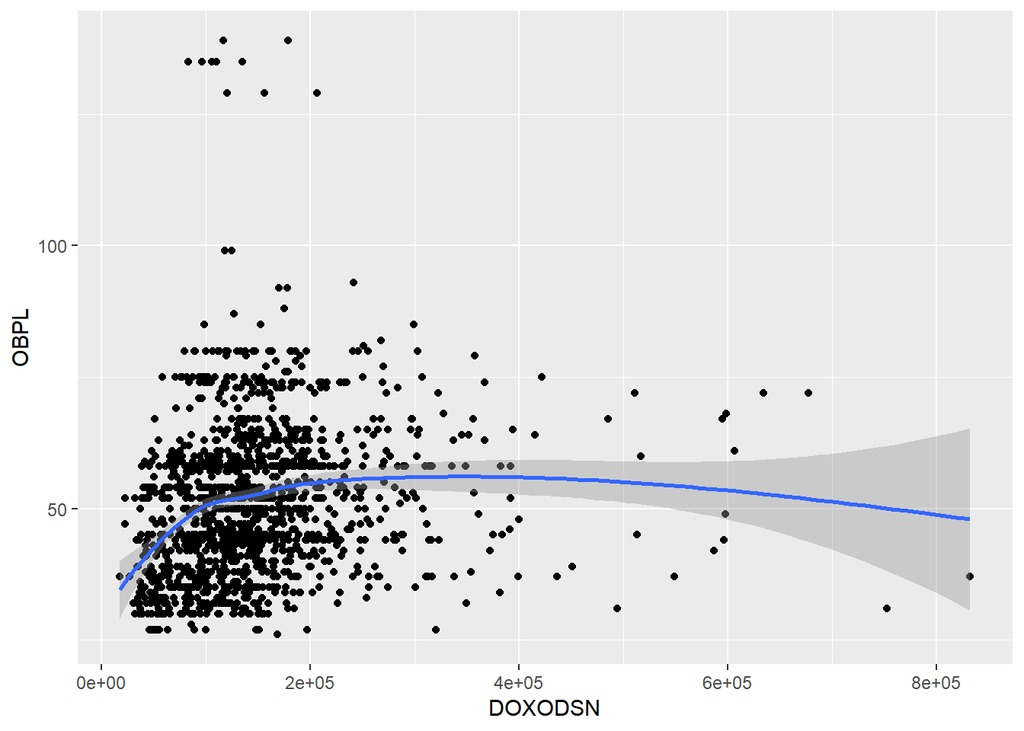

```r
ggplot(data = ob_fct, aes(x = DOXODSN, y = OBPL)) +
  geom_point() +
  geom_smooth(method = 'loess')
```

Теперь оценим более сложную модель. К объясняющим переменным добавим переменные - Потребительские расходы (POTRAS), Расходы на покупку продуктов питания (PROD), Расходы на оплату услуг (USLUG), Налиие автомобиля (RAVT) и Налоги, сборы, платежи (NALOG) .

```r
model_ur <- lm(data = ob_fct, OBPL ~ DOXODSN + POTRAS + PROD + USLUG + RAVT + NALOG)
summary(model_ur)
```

```
##
## Call:
## lm(formula = OBPL ~ DOXODSN + POTRAS + PROD + USLUG + RAVT +
##     NALOG, data = ob_fct)
##
## Residuals:
##     Min      1Q  Median      3Q     Max
## -33.003 -10.548  -1.814   8.023  86.526
##
## Coefficients:
##               Estimate Std. Error t value Pr(>|t|)
## (Intercept)  4.469e+01  9.933e-01  44.991  < 2e-16 ***
## DOXODSN     -2.157e-05  9.428e-06  -2.287 0.022317 *
## POTRAS      -3.532e-06  8.259e-06  -0.428 0.668949
## PROD         5.311e-05  2.468e-05   2.151 0.031610 *
## USLUG        1.396e-04  2.561e-05   5.452 5.88e-08 ***
## RAVT         8.097e-01  8.387e-01   0.965 0.334495
## NALOG        1.641e-04  4.675e-05   3.510 0.000462 ***
## ---
## Signif. codes:  0 '***' 0.001 '**' 0.01 '*' 0.05 '.' 0.1 ' ' 1
##
## Residual standard error: 14.49 on 1389 degrees of freedom
## Multiple R-squared:  0.06125,    Adjusted R-squared:  0.0572
## F-statistic:  15.1 on 6 and 1389 DF,  p-value: < 2.2e-16
```

Построенная модель включает два незначимых коэффициента - Наличие машины и потребительские расходы. Исключим эти коэффициенты и построим модель со всеми значимыми коэффииентами с использованием пошаговых алгоритмов РА.

```r
model_ur <- lm(data = ob_fct, OBPL ~ DOXODSN + PROD + USLUG + RAVT + NALOG)
summary(model_ur)
```

```
##
## Call:
## lm(formula = OBPL ~ DOXODSN + PROD + USLUG + RAVT + NALOG, data = ob_fct)
##
## Residuals:
##     Min      1Q  Median      3Q     Max
## -32.809 -10.432  -1.790   8.045  86.591
##
## Coefficients:
##               Estimate Std. Error t value Pr(>|t|)
## (Intercept)  4.471e+01  9.921e-01  45.065  < 2e-16 ***
## DOXODSN     -2.335e-05  8.460e-06  -2.759 0.005865 **
## PROD         5.063e-05  2.399e-05   2.111 0.034979 *
## USLUG        1.353e-04  2.351e-05   5.754 1.07e-08 ***
## RAVT         7.747e-01  8.345e-01   0.928 0.353374
## NALOG        1.677e-04  4.599e-05   3.646 0.000276 ***
## ---
## Signif. codes:  0 '***' 0.001 '**' 0.01 '*' 0.05 '.' 0.1 ' ' 1
##
## Residual standard error: 14.49 on 1390 degrees of freedom
## Multiple R-squared:  0.06113,    Adjusted R-squared:  0.05775
## F-statistic:  18.1 on 5 and 1390 DF,  p-value: < 2.2e-16
```

```r
model_ur <- lm(data = ob_fct, OBPL ~ DOXODSN + PROD + USLUG + NALOG)
summary(model_ur)
```

```
##
## Call:
## lm(formula = OBPL ~ DOXODSN + PROD + USLUG + NALOG, data = ob_fct)
##
## Residuals:
##     Min      1Q  Median      3Q     Max
## -33.882 -10.392  -1.859   8.025  86.426
##
## Coefficients:
##               Estimate Std. Error t value Pr(>|t|)
## (Intercept)  4.466e+01  9.905e-01  45.086  < 2e-16 ***
## DOXODSN     -2.152e-05  8.229e-06  -2.616 0.009003 **
## PROD         4.815e-05  2.384e-05   2.020 0.043588 *
## USLUG        1.361e-04  2.349e-05   5.793 8.54e-09 ***
## NALOG        1.726e-04  4.568e-05   3.778 0.000165 ***
## ---
## Signif. codes:  0 '***' 0.001 '**' 0.01 '*' 0.05 '.' 0.1 ' ' 1
##
## Residual standard error: 14.49 on 1391 degrees of freedom
## Multiple R-squared:  0.06055,    Adjusted R-squared:  0.05784
## F-statistic: 22.41 on 4 and 1391 DF,  p-value: < 2.2e-16
```

Таким образом, посроена статистически значимая регрессионная модель со всеми значимыми коэффициентами. Неожиданным является отрицательный знак при переменной Доход.Модель нуждается в дополнительной диагностике!

[figure not shown]

```r
ggnostic(model = model_ur)
```

На этом графике четыре линии! * Первая: зависимость величины остатка $\hat u_i = y_i - \hat y_i$ от каждого регрессора. * Вторая: зависимость величины $\hat \sigma_i$ от каждого регрессора.

Величина $\hat \sigma_i$ показывает, какой была бы оценка стандартного отклонения случайной составляющей, если бы $i$-ое наблюдение выкинули из модели.

Слишком маленькие значения $\hat \sigma_i$ говорят о том, что при выкидывании наблюдения резко падает оценка стандартного отклонения. Значит, наблюдение могло быть выбросом.

- Третья: зависимость величины $h_{ii}$ от каждого регрессора.

Величина $h_{ii}$ имеет две интерпретации. Во-первых, она показывает, насколько изменится прогноз $\hat y_i$ при увеличении фактического наблюдения $y_i$ на единицу. Во-вторых, эта величина показывает отношение дисперсии прогноза $\hat y_i$ к дисперсии случайной составляющей:
$$h_{ii} = \frac{Var(\hat y_i)}{Var(u_i)}$$

- Четвертая: зависимость расстояния Кука от каждого из регрессоров.

Расстояние Кука показывает, насколько сильно изменятся прогнозы по всему набору данных, при выкидывании $i$-го наблюдения,

```r
coefci(model_ur, level = 0.95)
```

```
##                     2.5 %        97.5 %
## (Intercept)  4.271479e+01  4.660090e+01
## DOXODSN     -3.766444e-05 -5.380896e-06
## PROD         1.387363e-06  9.490591e-05
## USLUG        9.000433e-05  1.821694e-04
## NALOG        8.298157e-05  2.621948e-04
```

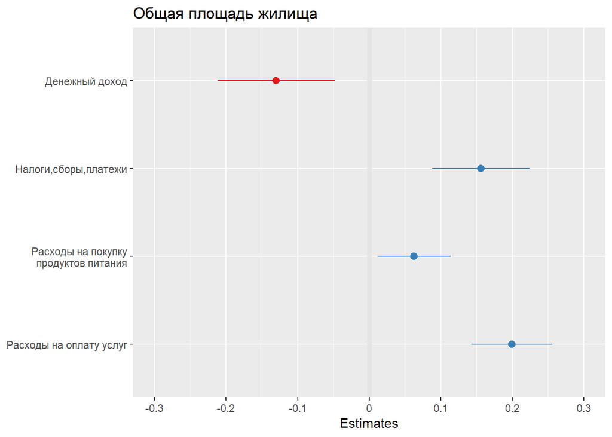

```r
plot_model(model_ur, type='std', ci.lvl = 0.9)
```

Диагностика мультиколлинеарности. Коэффициенты вздутия дисперсии

```r
vif(model_ur)
```

```
##  DOXODSN     PROD    USLUG    NALOG
## 3.656687 1.432211 1.757496 2.533018
```

Если есть две вложенных модели, то есть одна является частным случаем другой, то можно провести тест Вальда, чтобы выбрать одну из них.

$H_0$: верна ограниченная (короткая) модель;

$H_1$: верная неограниченная (длинная) модель;

```r
waldtest(model_r, model_ur)
```

```
## Wald test
##
## Model 1: OBPL ~ DOXODSN
## Model 2: OBPL ~ DOXODSN + PROD + USLUG + NALOG
##   Res.Df Df      F    Pr(>F)
## 1   1394
## 2   1391  3 18.357 1.106e-11 ***
## ---
## Signif. codes:  0 '***' 0.001 '**' 0.01 '*' 0.05 '.' 0.1 ' ' 1
```

Сравнение p-значений позволяет сделать вывод, что длинаая модель дает прирост информативности, поэтому ее предпочтительнее использовать при моделировании OBPL (выбираем вторую модель).

# 2 Регрессия при гетероскедастичных ошибках

Построим табличку с тестами на значимость отдельных коэффициентов с учётом поправки на гетероскедастичность.

```r
coeftest(model_ur, vcov. = vcovHC)
```

```
##
## t test of coefficients:
##
##                Estimate  Std. Error t value  Pr(>|t|)
## (Intercept)  4.4658e+01  9.2115e-01 48.4805 < 2.2e-16 ***
## DOXODSN     -2.1523e-05  9.5992e-06 -2.2421  0.025110 *
## PROD         4.8147e-05  2.1359e-05  2.2542  0.024341 *
## USLUG        1.3609e-04  2.8034e-05  4.8544 1.344e-06 ***
## NALOG        1.7259e-04  5.4590e-05  3.1615  0.001603 **
## ---
## Signif. codes:  0 '***' 0.001 '**' 0.01 '*' 0.05 '.' 0.1 ' ' 1
```

Рассмотрим доверительные интервалы:

```r
coefci(model_ur, vcov. = vcovHC)
```

```
##                     2.5 %        97.5 %
## (Intercept)  4.285085e+01  4.646484e+01
## DOXODSN     -4.035314e-05 -2.692197e-06
## PROD         6.247310e-06  9.004596e-05
## USLUG        8.109349e-05  1.910802e-04
## NALOG        6.550033e-05  2.796761e-04
```

Сравним две вложенных модели с учётом поправки на гетероскедастичность:

```r
waldtest(model_r, model_ur, vcov = vcovHC)
```

```
## Wald test
##
## Model 1: OBPL ~ DOXODSN
## Model 2: OBPL ~ DOXODSN + PROD + USLUG + NALOG
##   Res.Df Df      F   Pr(>F)
## 1   1394
## 2   1391  3 12.946 2.42e-08 ***
## ---
## Signif. codes:  0 '***' 0.001 '**' 0.01 '*' 0.05 '.' 0.1 ' ' 1
```

Результаты оценивания показыают, что вторая модель (с учётом поправки на гетероскедастичность), предпочтительнее.